# HW09

Chongdan Pan

2022-04-02

## Question 1

$$\gamma(h)=\text{Cov}(X_{n+h},X_n)=\text{Cov}(\sum_{i=-\infty}^\infty\psi_i\epsilon_{n-i},\sum_{j=-\infty}^\infty\psi_j\epsilon_{n+h-j})\\
\gamma(h)=\text{Cov}(\sum_{i=-\infty}^\infty\psi_i\epsilon_{n-i},\sum_{i=-\infty}^\infty\psi_{i+h}\epsilon_{n-i})=\sum_{i=-\infty}^\infty\psi_i\psi_{i+h}\sigma^2$$

## Question 2

1. $$(1-\alpha_1B)X_n=(1+\theta_1B+\theta_2B^2)\epsilon_n\\
   X_n=\frac{1+\theta_1B+\theta_2B^2}{1-\alpha_1B}\epsilon_n=\sum_{i=0}^\infty\alpha_1^iB^i(1+\theta_1B+\theta_2B^2)\epsilon_n=\sum_{i=0}^\infty\alpha_1^i(1+\theta_1B+\theta_2B^2)\epsilon_{n-i}\\
   X_n=\sum_{i=0}^\infty\alpha_1^i(\epsilon_{n-i}+\theta_1\epsilon_{n-i-1}+\theta_2\epsilon_{n-i-2})=\epsilon_n+(\theta_1+\alpha_1)\epsilon_{n-1}+\sum_{i=0}^\infty\alpha_1^i(\theta_2+\alpha_1\theta_1+\alpha_1^2)\epsilon_{n-2-i}$$
2. Based on the result from question 1, we have

$$\gamma(h)=\sum_{i=-\infty}^\infty\psi_i\psi_{i+h}\sigma^2=\sum_{i=0}^\infty\psi_i\psi_{i+h}\sigma^2\\
\text{When }
h=0\quad\gamma(h)=[1+(\alpha+\theta_1)^2+\sum_{i=0}^\infty\alpha_1^{2i}(\alpha_1^2+\alpha_1\theta_1+\theta_2)^2]\sigma^2
\\
\text{When } h=\pm1\quad
\gamma(h)=[(\alpha_1+\theta_1)(1+\alpha_1^2+\alpha_1\theta_1+\theta_2)+\sum_{i=0}^\infty\alpha_1^{2i+1}(\alpha_1^2+\alpha_1\theta_1+\theta_2)^2]\sigma^2
\\
\text{When } h \geq 2 \text{ or } h\leq-2\quad
\gamma(h)=\sum_{i=0}^\infty(\theta_2+\alpha_1\theta_1+\alpha_1^2)[1+\theta_1\alpha_1+(1+\theta_2)\alpha_1^2+\alpha_1^3\theta_1+\alpha_1^4]\alpha_1^{|h|-2+i}\sigma^2\\$$

## Question 3

```r
X = read.csv("../NYA-2015-2017.csv",header=TRUE)
library(tseries)
NYSE_lret = diff(log(X$AdjClose))
NYSE_lret.ts <- ts(data=NYSE_lret,start=c(2015,1),frequency=252,names=c('logret'))
```

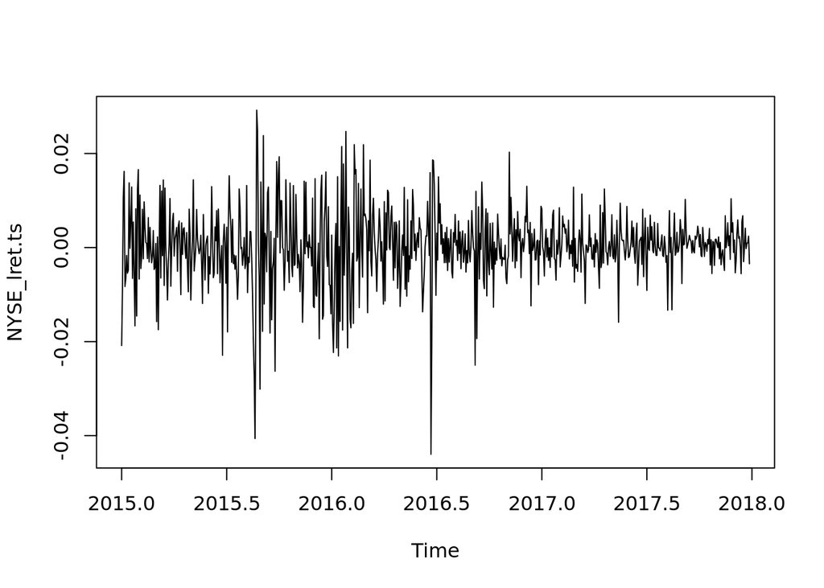

```r
plot(NYSE_lret.ts)
```

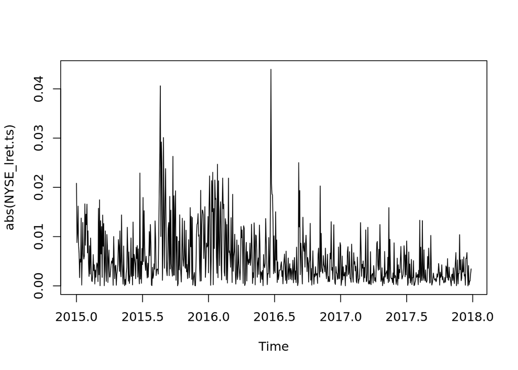

```r
plot(abs(NYSE_lret.ts))
```

Based on the plot, it looks like we can use a ARCH model to fit the absolute return, which is volatility because there is chance that the volatility at time $t$ may depend on it at $t-1$.

```r
model <- garch(NYSE_lret.ts, order=c(1,1))
```

[output not shown]

```r
summary(model)
```

```
##
## Call:
## garch(x = NYSE_lret.ts, order = c(1, 1))
##
## Model:
## GARCH(1,1)
##
## Residuals:
##      Min       1Q   Median       3Q      Max
## -5.25462 -0.48218  0.04271  0.63034  3.89839
##
## Coefficient(s):
##     Estimate  Std. Error  t value Pr(>|t|)
## a0 2.926e-06   6.321e-07    4.630 3.66e-06 ***
## a1 1.659e-01   2.035e-02    8.153 4.44e-16 ***
## b1 7.875e-01   2.730e-02   28.851  < 2e-16 ***
## ---
## Signif. codes:  0 '***' 0.001 '**' 0.01 '*' 0.05 '.' 0.1 ' ' 1
##
## Diagnostic Tests:
##  Jarque Bera Test
##
## data:  Residuals
## X-squared = 238, df = 2, p-value < 2.2e-16
##
##
##  Box-Ljung test
##
## data:  Squared.Residuals
## X-squared = 0.53557, df = 1, p-value = 0.4643
```

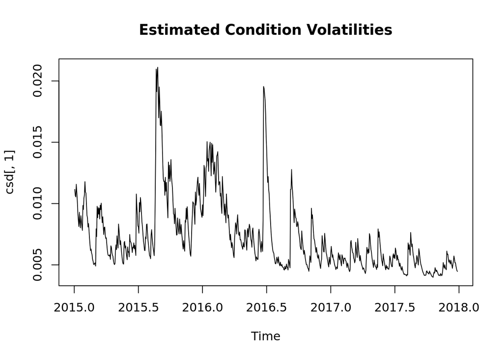

```r
csd <- fitted.values(model)
plot(csd[,1])
title(main="Estimated Condition Volatilities")
```

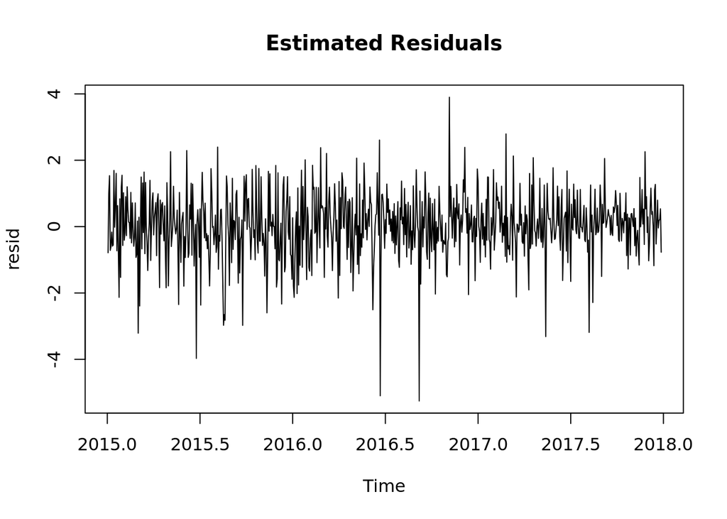

```r
resid <- residuals(model)
plot(resid)
title(main="Estimated Residuals")
```

```r
sd(na.omit(resid))
```

```
## [1] 1.00024
```

```r
mean(na.omit(resid))
```

```
## [1] 0.02782612
```

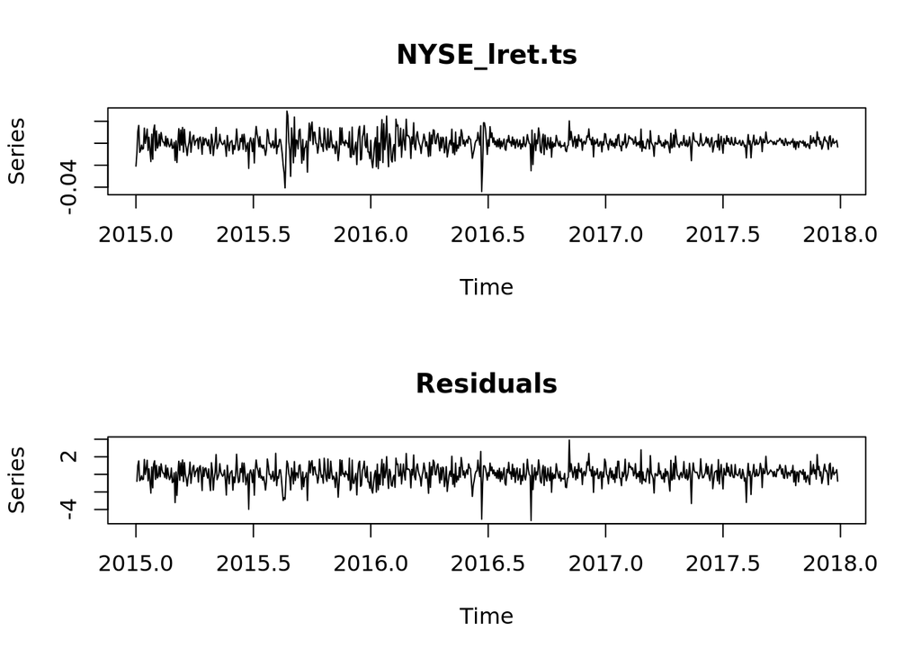

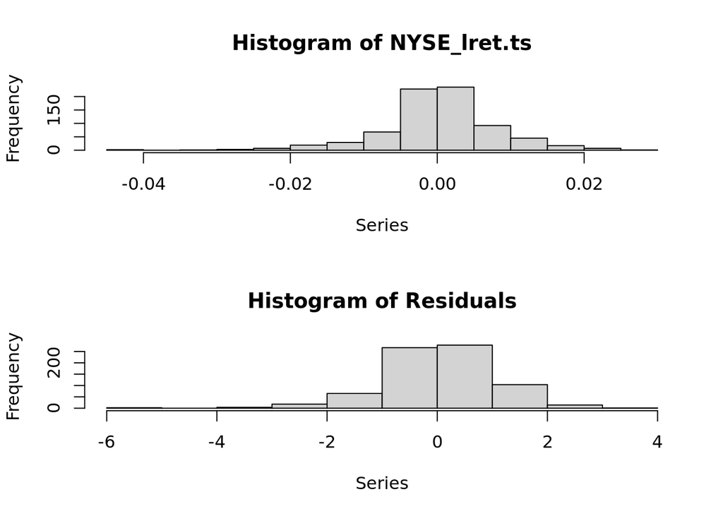

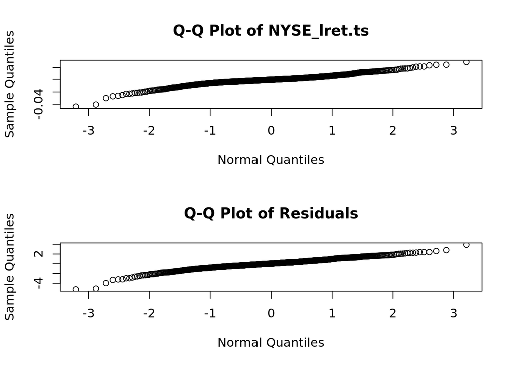

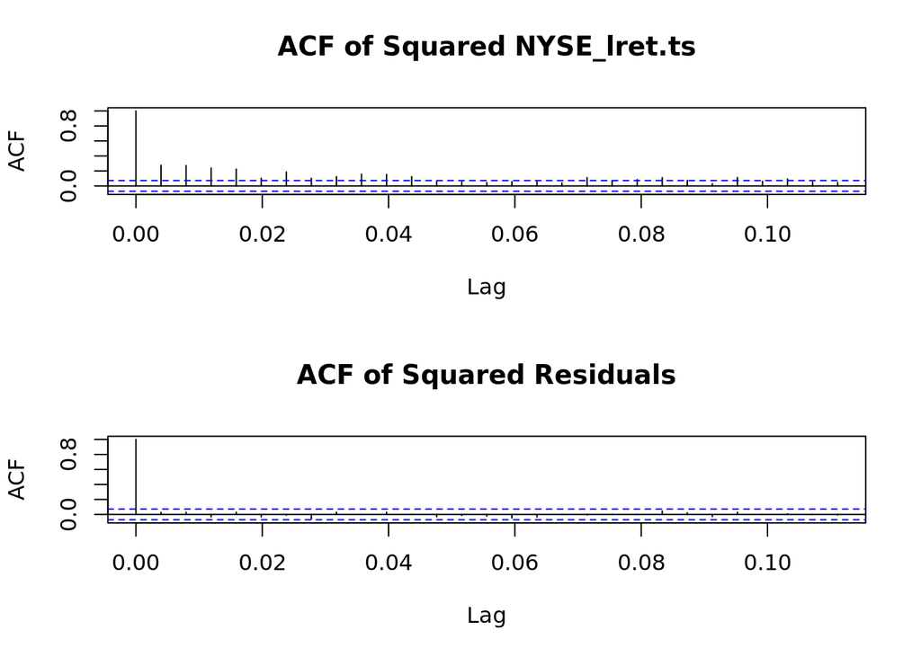

```r
plot(model)
```

The mean and standard deviation of the residual is close to 0 and 1 respectively, implying that our code is working/ However, from the Q-Q plot of the residuals, it turns out we have heavy tails, which conform to the result from the Jarque Bera test. Since the P-value of the Box-Ljung test is large, we don’t have significant evidence showing that the residuals are auto-correlated, which also conforms to the ACF plot. The value of $\alpha_0$ is quite small, implying that the lower bound of the volatility is small. In summary, our model does capture the time-series relation within the volatility, but we still need some way to deal with the heavy tail residuals.

Since the return’s mean is extremely close to 0, we will assume $\mu_n=0$ in this case.

```r
sigma = (coef(model)[1] + coef(model)[3] * csd[754] ^ 2 + coef(model)[2] * NYSE_lret.ts[754] ^ 2) ^ 0.5
var = exp(-qnorm(0.005) * sigma) - 1
var
```

```
##        a0
## 0.0117686
```

Therefore we have relative VaR to be 0.0118

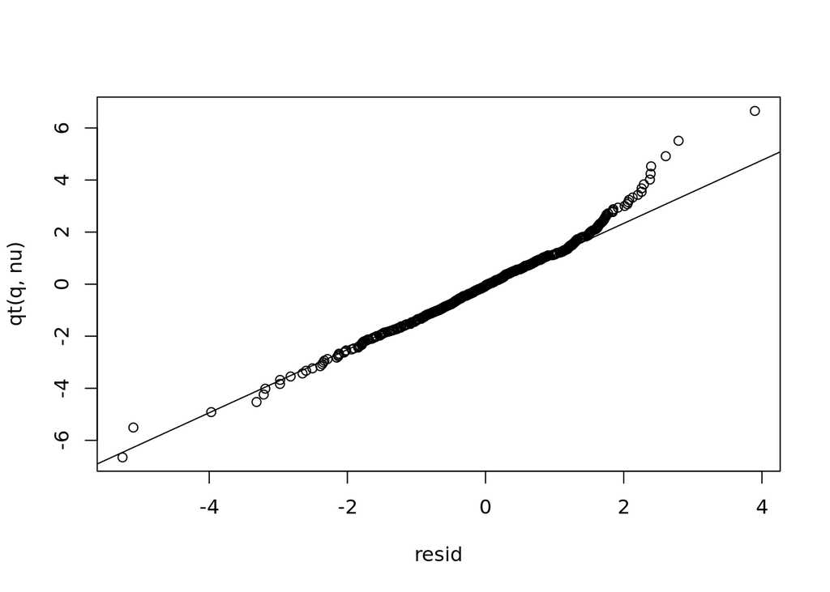

```r
q <- (1:length(NYSE_lret.ts)) / (length(NYSE_lret.ts) + 1)
nu <- 4
qqplot(resid, qt(q, nu))
qqline(resid, qt(q, nu))
```

I’m using a t-distribution with degree of freedom to be 4 for fitting. Although we have a thin right tail, the left tail is well-fit, which is critical to the calculation of VaR.

```r
lambda = sqrt(sigma^2*(nu-2)/nu)
var = exp(-qt(0.005, nu) * lambda) - 1
var
```

```
##         a0
## 0.01489734
```

Therefore, we have relative VaR based on T-distribution to be 0.0149

```r
day = which.max(csd)
day
```

```
## [1] 165
```

```r
sigma = (coef(model)[1] + coef(model)[3] * csd[day-1] ^ 2 + coef(model)[2] * NYSE_lret.ts[day-1] ^ 2) ^ 0.5
var = -qnorm(0.005) * sigma
var = exp(var) - 1
var
```

```
##         a0
## 0.05589439
```

The index we have max volatility is 165 Therefore we have relative VaR to be 0.056 from normal distributed residual.

```r
lambda = sqrt(sigma^2*(nu-2)/nu)
var = exp(-qt(0.005, nu) * lambda) - 1
var
```

```
##         a0
## 0.07115888
```

Therefore, we have relative VaR based on T-distribution to be 0.071